# Beware Tornadoes: Economic and Human Casualties, 1950-2011

### Reproducible Research, Project 2

## Synopsis

Tornadoes injured or killed the most people and were the 3rd leading cause of economic damage in the period 1950-2011.

A review of the NOAA Storm Database shows that, over the period of 1950-2011, tornadoes in the United States caused 91346 injuries, 5633 fatalities, and $56.937 billion in economic property damage.

## Questions to be addressed

1. Across the United States, which types of events (as indicated in the `EVTYPE` variable) are most harmful with respect to population health?
2. Across the United States, which types of events have the greatest economic consequences?

## Data Processing

1. Read in the data

```r
StormData <- read.csv(bzfile("C:/Users/Cire/Documents/R/Sandbox/repdata-data-StormData.csv.bz2"))
```

1. Subset the data… we don’t need all the columns

```r
columns <- c("BGN_DATE", "BGN_TIME", "STATE", "EVTYPE", "FATALITIES",
             "INJURIES", "PROPDMG", "PROPDMGEXP")
StormData <- StormData[,columns]
```

1. Clean PROPDMGEXP and create a new column with actual damage values

```r
# Get rid of NA values
StormData <- subset(StormData, StormData$PROPDMGEXP!='+' &
                    StormData$PROPDMGEXP!='-' &
                    StormData$PROPDMGEXP!='?')

StormData$PROPDMGEXP <- toupper(StormData$PROPDMGEXP)

# PROPDMGEXP gives the 'exponent' value of the property damage
old_vals <- c('0', '1', '2', '3', '4', '5', '6', '7', '8', 'H', 'K', 'M', 'B',
              '')
new_vals <- c(1, 0.1*10^3, 0.2*10^3, 0.3*10^3, 0.4*10^3, 0.5*10^3, 0.6*10^3,
              0.7*10^3, 0.8*10^3, 10^2, 10^3, 10^6, 10^9, 1)

for(idx in 1:length(old_vals)){
  StormData[StormData$PROPDMGEXP == old_vals[idx], ]$PROPDMGEXP <- new_vals[idx]
  }

# Add in new column with real property damage value
StormData$Damage <- as.numeric(StormData$PROPDMG) * as.numeric(StormData$PROPDMGEXP)
```

1. Calculate injuries, fatalities, and property damage

```r
Totals.Injuries <- aggregate(formula = INJURIES ~ EVTYPE,
                             data = StormData,
                             FUN = sum)
# Sort by most injuries
Totals.Injuries <- Totals.Injuries[order(x = Totals.Injuries$INJURIES,
                                         decreasing = TRUE), ]
# Now for fatalities
Totals.Fatalities <- aggregate(formula = FATALITIES ~ EVTYPE,
                             data = StormData,
                             FUN = sum)
# Sort by most fatalities
Totals.Fatalities <- Totals.Fatalities[order(x = Totals.Fatalities$FATALITIES,
                                         decreasing = TRUE), ]
# And now for property damage
Totals.Damage <- aggregate(formula = Damage ~ EVTYPE,
                           data = StormData,
                           FUN = sum)
# Sort by most damage
Totals.Damage <- Totals.Damage[order(x = Totals.Damage$Damage,
                                         decreasing = TRUE), ]
```

## Results

Here’s a barplot of the top 5 storm sources of injuries:

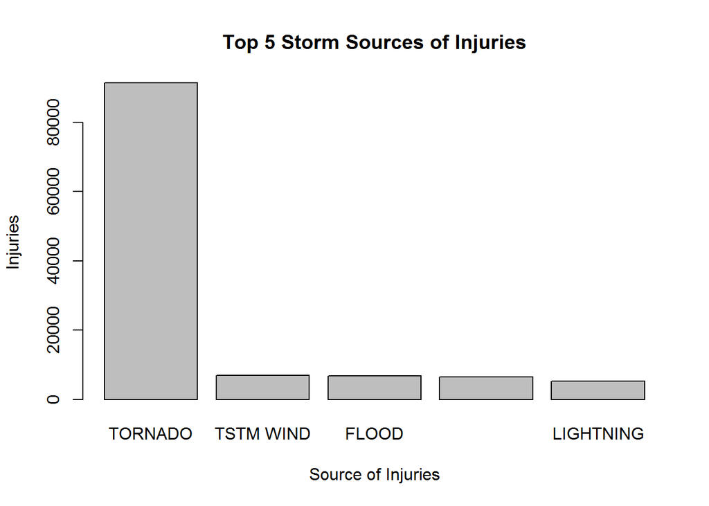

```r
barplot(height = Totals.Injuries$INJURIES[1:5],
        names.arg = Totals.Injuries$EVTYPE[1:5],
        main = "Top 5 Storm Sources of Injuries",
        xlab = "Source of Injuries",
        ylab = "Injuries")
```

Here is a barplot of the top 5 storm sources of fatalities:

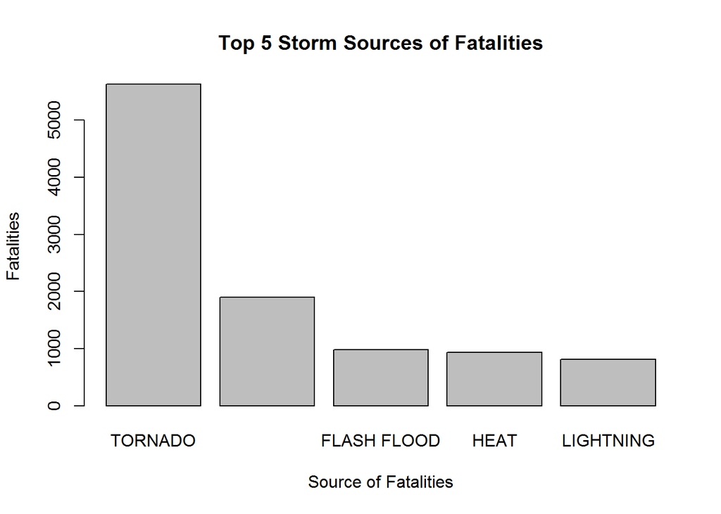

```r
barplot(height = Totals.Fatalities$FATALITIES[1:5],
        names.arg = Totals.Fatalities$EVTYPE[1:5],
        main = "Top 5 Storm Sources of Fatalities",
        xlab = "Source of Fatalities",
        ylab = "Fatalities")
```

Again, Tornado is the overwhelming source of fatalities over the period with 5633 fatalities.

And, finally, here is a barplot of the top 5 storm sources of economic damage:

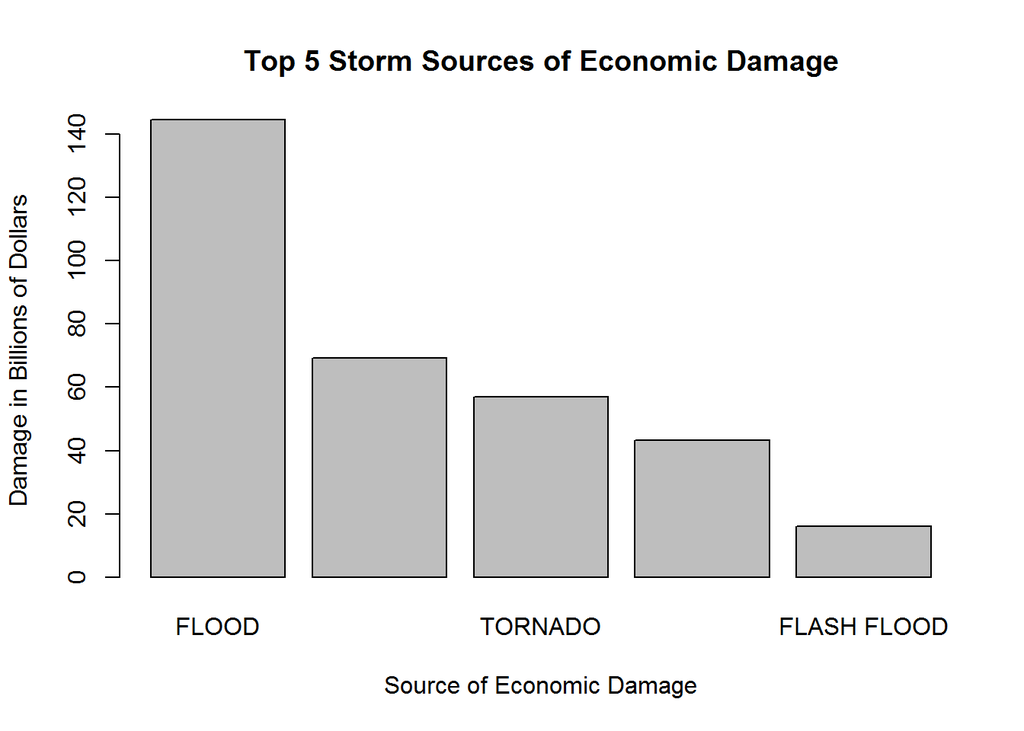

```r
barplot(height = Totals.Damage$Damage[1:5]/10^9,
        names.arg = Totals.Damage$EVTYPE[1:5],
        main = "Top 5 Storm Sources of Economic Damage",
        xlab = "Source of Economic Damage",
        ylab = "Damage in Billions of Dollars")
```

We can see that flooding and hurricanes/typhoons were the only 2 event types that caused more economic impact than tornados over the period in question. Flooding caused $144.6577098 billion in damages, hurricanes/typhoons caused $69.30584 billion in damages, and tornados caused $56.9372249 billion in damages.